# survival power exploration

# 3 Exponential distributions, a change in survival time fixed survival probability

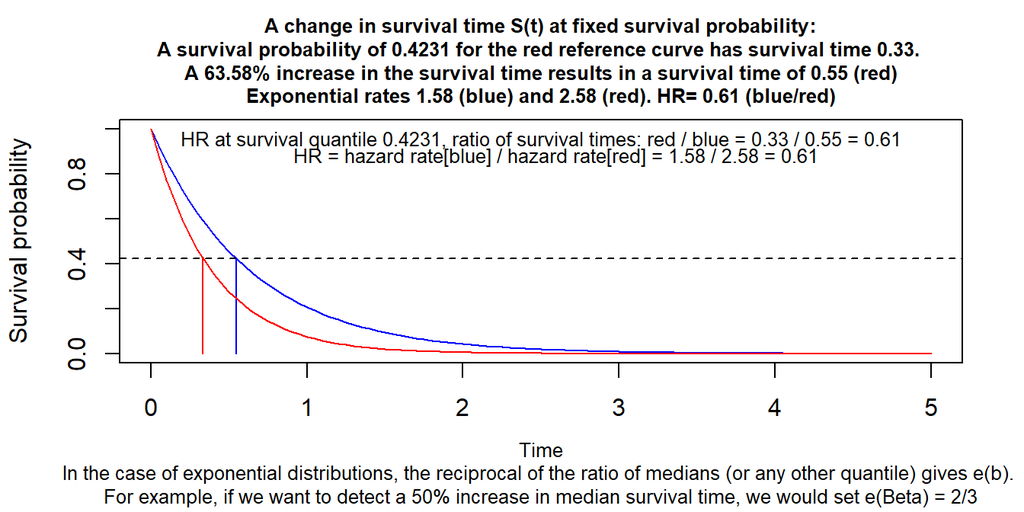

```r
 #~~~~~~~~~~~~~~~~~~~~~~~~~~~~~~~~~~~~~~~~~~~~~~~~~~~~~~~~~~~~~~~~~~~~~~~~~~~~~~~~~~~~~~~~~~~~~~~~
 p          <- mort1
 ref.time   <- time
 trt.time   <- -log(p)/lambda
 fact.      <- (-log(p)/lambda)  / (-log(p)/lambda2) -1
#~~~~~~~~~~~~~~~~~~
 curve(zp(x, shape=1, scale=1/lambda), from=0, to=end,
       main=paste0(  "A change in survival time S(t) at fixed survival probability:\nA survival probability of ",
          formatz4(p),         " for the red reference curve has survival time ",
          formatz2( ref.time), ". \nA ",
          formatz2(fact.*100), "% increase in the survival time results in a survival time of ",
          formatz2(trt.time),  " (red)\nExponential rates ",
          formatz2(lambda),    " (blue) and ",
          formatz2(lambda2),   " (red). HR= ",
          formatz2(hr),        " (blue/red)"
          ),
          cex.main = .8,
          ylab='Survival probability',xlab='',
          col="blue",
          sub= "Time\nIn the case of exponential distributions, the reciprocal of the ratio of medians (or any other quantile) gives e(b). \nFor example, if we want to detect a 50% increase in median survival time, we would set e(Beta) = 2/3" , cex.sub=.8)
   #~~~~~~~~~~~~~~~~~~
   text(x = end*.5, y = .95,
       paste0("HR at survival quantile ",
              formatz4(p),                     ", ratio of survival times: red / blue = ",
              formatz2(ref.time),              " / ",
              formatz2(trt.time),              " = ",
              formatz2( ref.time/trt.time ),   ""),
       col = "black",
       cex = .8)
  #~~~~~~~~~~~~~~~~~~
  text(x = end*.52, y = .875,
       paste0(expression("HR = hazard rate[blue] / hazard rate[red] = "),
              formatz2(lambda)," / ",formatz2(lambda2)," = ",
              formatz2(lambda/lambda2),""
              ),
       col = "black",
             cex = .8)
 #~~~~~~~~~~~~~~~~~~~
 abline(h=p , col='black' , lty=2)
 lines(c(-log(p)/lambda2 , -log(p)/lambda2), c(0 , p) , col='red')
 lines(c(-log(p)/lambda  , -log(p)/lambda),  c(0 , p) , col='blue')
 #~~~~~~~~~~~~~~~~~~~
 curve(zp(x, shape=1, scale=1/lambda2), from=0, to=end,
       ylab='Survival probability', xlab='Time', col="red", add=TRUE)
```

```r
 #~~~~~~~~~~~~~~~~~~~~~~~~~~~~~~~~~~~~~~~~~~~~~~~~~~~~~~~~~~~~~~~~~~~~~~~~~~~~~~~~~~~~~~~~~~~~~~~~
```

# 4 Example 1. Reproduce Nquery example with Hmisc::cpower

Reproduce Nquery example “Using an unstratified log-rank test at the one-sided 2.5% significance level, a total of 282 events would allow 92.6% power to demonstrate a 33% risk reduction (hazard ratio for RAD/placebo of about 0.67, as calculated from an anticipated 50% increase in median PFS, from 6 months in placebo arm to 9 months in the RAD001 arm). With a uniform accrual of approximately 23 patients per month over 74 weeks and a minimum follow up of 39 weeks, a total of 352 patients would be required to obtain 282 PFS events, assuming an exponential progression-free survival distribution with a median of 6 months in the Placebo arm and of 9 months in RAD001 arm. With an estimated 10% lost to follow up patients, a total sample size of 392 patients should be randomized.”

```r
# This function is useful for creating d1 an input to Hmisc cpower to find the intervention mortality at same time

  morti <- function ( d0=.5, hr=2/3, time=6){

      lambda = -log(1-d0)/time     # hazard rate
      m = 1 - exp(-lambda*time*hr) # mortality hence subtracting from 1
      return(m)
  }


  d0 <- 0.5      # control mortality at 6 months
  d1 <- morti()  # interv. mortality at 6 months
  # r is the % reduction ctrl to intervention

  cpower(tref=6, n=352, mc=d0, r= 100*(d0 - d1)/d0, tmin=39/4,  #mc is  tref-year mortality, control
         accrual=74/4, alpha=.05, pr=TRUE,
         noncomp.c = 0, noncomp.i = 0)
```

Accrual duration: 18.5 y Minimum follow-up: 9.75 y

Total sample size: 352

Alpha= 0.05

6-year Mortalities Control Intervention 0.5000000 0.3700395

Hazard Rates Control Intervention 0.11552453 0.07701635

Probabilities of an Event During Study Control Intervention 0.8661998 0.7484495

Expected Number of Events Control Intervention 152.5 131.7

Hazard ratio: 0.6666667 Standard deviation of log hazard ratio: 0.1189577 Power 0.9262639

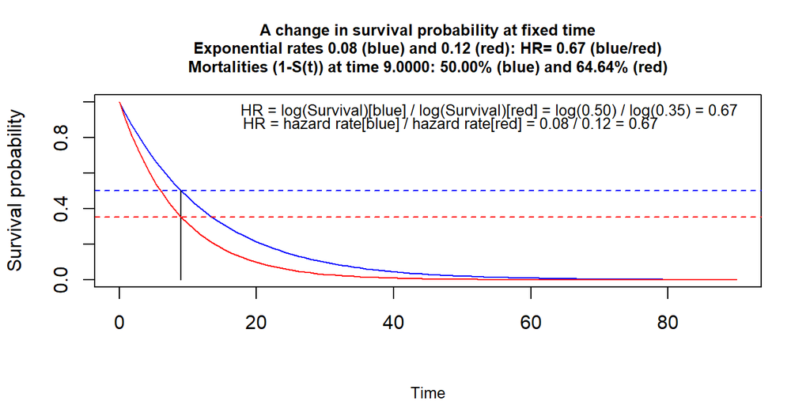

```r
  survP(0.07701635,0.11552453,.5)  # intervention haz, ctrl hazard, Surv prob in ctrl
```

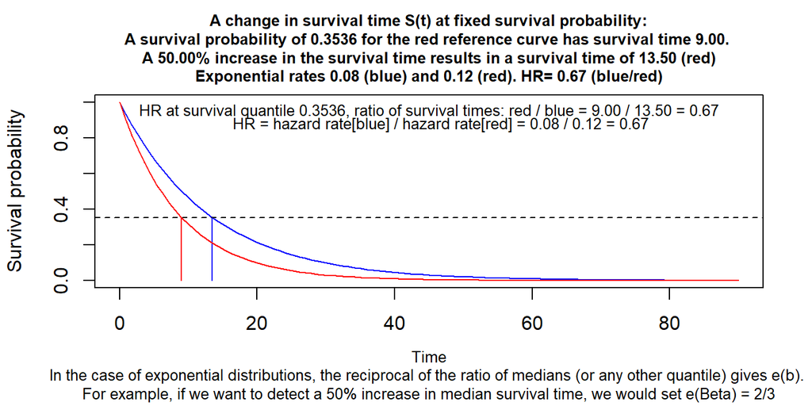

```r
  SurvP2(0.07701635,0.11552453,.5) # intervention haz, ctrl hazard, Surv prob in ctrl
```

```r
cat("Plots just to gain understanding and do not examine accrual not follow up times.")
```

Plots just to gain understanding and do not examine accrual not follow up times.

# 5 Example 2. Reproduce published example with Hmisc::cpower

we duplicate the paper https://www.ncbi.nlm.nih.gov/pmc/articles/PMC3405221/ We needed 444 patients to detect an increase in 1-year survival from 29 to 40% with 80% power at a 5% significance level, assuming an accrual time of 52 weeks and a minimum follow-up time of 52 weeks.

```r
d0 <- 1-.29
d1 <- 1-.4
cpower(tref=1, n=444, mc=d0, r= 100*(d0 - d1)/d0, tmin=1,
       accrual=1, alpha=.05, pr=TRUE,
       noncomp.c = 0, noncomp.i = 0)
```

Accrual duration: 1 y Minimum follow-up: 1 y

Total sample size: 444

Alpha= 0.05

1-year Mortalities Control Intervention 0.71 0.60

Hazard Rates Control Intervention 1.2378744 0.9162907

Probabilities of an Event During Study Control Intervention 0.8336665 0.7380744

Expected Number of Events Control Intervention 185.1 163.9

Hazard ratio: 0.740213 Standard deviation of log hazard ratio: 0.1072674 Power 0.8007791

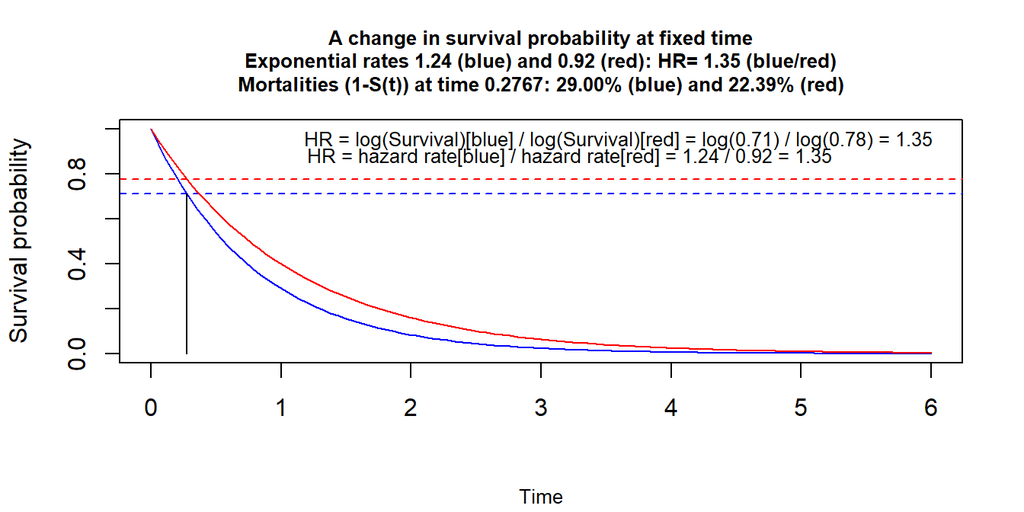

```r
    # the hazards come from cpower function
    survP(1.2378744 ,   0.9162907 ,.29)  # intervention haz, ctrl hazard, Surv prob in ctrl
```

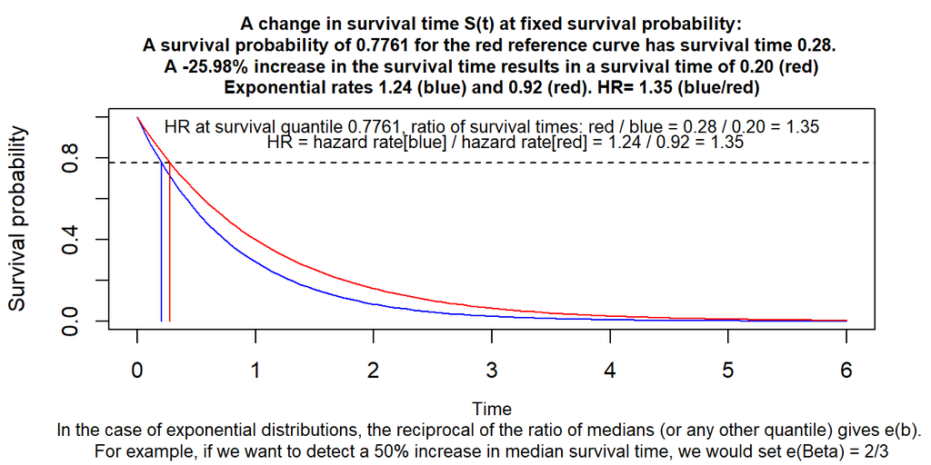

```r
    SurvP2(1.2378744 ,   0.9162907 ,.29) # intervention haz, ctrl hazard, Surv prob in ctrl
```

```r
cat("Plots just to gain understanding and do not examine accrual not follow up times.")
```

Plots just to gain understanding and do not examine accrual not follow up times.

# 6 Example 3 cpower help file

Duplicate the Hmisc help file example Simulate a simple 2-arm clinical trial with exponential survival so we can compare power simulations of logrank-Cox test with cpower() Hazard ratio is constant and patients enter the study uniformly with follow-up ranging from 1 to 3 years Drop-in probability is constant at .1 and drop-out probability is constant at .175. Two-year survival of control patients in absence of drop-in is .8 (mortality=.2). Note that hazard rate is -log(.8)/2 Total sample size (both groups combined) is 1000 % mortality reduction by intervention (if no dropin or dropout)  
is 25. This corresponds to a hazard ratio of 0.7283 (computed by cpower)

```r
cpower(tref=2, n=1000, mc=.2, r=25, accrual=2, tmin=1,
       noncomp.c=10, noncomp.i=17.5)
```

Accrual duration: 2 y Minimum follow-up: 1 y

Total sample size: 1000

Alpha= 0.05

2-year Mortalities Control Intervention 0.20 0.15

Hazard Rates Control Intervention 0.11157178 0.08125946

Probabilities of an Event During Study Control Intervention 0.1983392 0.1490643

Expected Number of Events Control Intervention 99.2 74.5

Hazard ratio: 0.7283156

Drop-in rate (controls):10% Non-adherence rate (intervention):17.5% Effective hazard ratio with non-compliance: 0.7946607 Standard deviation of log hazard ratio: 0.1532996 Power 0.322786

```r
# repeating using my function, only difference due to rounding

  d0= .2
  time=2
  hr=0.7283
  d1 <- morti(d0=d0, hr= hr, time=time)

  cpower(tref=time, n=1000, mc=d0, r=100*(d0 - d1)/d0, accrual=2, tmin=1,
         noncomp.c=10, noncomp.i=17.5)
```

Accrual duration: 2 y Minimum follow-up: 1 y

Total sample size: 1000

Alpha= 0.05

2-year Mortalities Control Intervention 0.200000 0.149997

Hazard Rates Control Intervention 0.11157178 0.08125772

Probabilities of an Event During Study Control Intervention 0.1983392 0.1490613

Expected Number of Events Control Intervention 99.2 74.5

Hazard ratio: 0.7283

Drop-in rate (controls):10% Non-adherence rate (intervention):17.5% Effective hazard ratio with non-compliance: 0.7946483 Standard deviation of log hazard ratio: 0.1533005 Power 0.3228192

# 7 Example 4 David Collett Modelling survival data in medical research-CRC Press (2015)

```r
  d0= .6
  time=5
  d1=.41

  cpower(tref=time, n=400, mc=d0, r=100*(d0 - d1)/d0, accrual=1.5, tmin=2,    # p478 and p482
         noncomp.c=0, noncomp.i=0)
```

Accrual duration: 1.5 y Minimum follow-up: 2 y

Total sample size: 400

Alpha= 0.05

5-year Mortalities Control Intervention 0.60 0.41

Hazard Rates Control Intervention 0.1832581 0.1055265

Probabilities of an Event During Study Control Intervention 0.3939625 0.2511033

Expected Number of Events Control Intervention 78.8 50.2

Hazard ratio: 0.5758355 Standard deviation of log hazard ratio: 0.1805649 Power 0.8636224

```r
  cpower(tref=time, n=400, mc=d0, r=100*(d0 - d1)/d0, accrual=2.0,  tmin=2,    # p483
         noncomp.c=0, noncomp.i=0)
```

Accrual duration: 2 y Minimum follow-up: 2 y

Total sample size: 400

Alpha= 0.05

5-year Mortalities Control Intervention 0.60 0.41

Hazard Rates Control Intervention 0.1832581 0.1055265

Probabilities of an Event During Study Control Intervention 0.4196845 0.2700099

Expected Number of Events Control Intervention 83.9 54.0

Hazard ratio: 0.5758355 Standard deviation of log hazard ratio: 0.1744464 Power 0.8856955

```r
  cpower(tref=time, n=903, mc=d0, r=100*(d0 - d1)/d0, accrual=20/24, tmin=0,  # p483 no this does not match <-!!
         noncomp.c=0, noncomp.i=0)
```

Accrual duration: 0.8333333 y Minimum follow-up: 0 y

Total sample size: 903

Alpha= 0.05

5-year Mortalities Control Intervention 0.60 0.41

Hazard Rates Control Intervention 0.1832581 0.1055265

Probabilities of an Event During Study Control Intervention 0.07261456 0.04270837

Expected Number of Events Control Intervention 32.8 19.3

Hazard ratio: 0.5758355 Standard deviation of log hazard ratio: 0.2869859 Power 0.4853908

# 8 Example 5 Stata survival manual

```r
# Stata survival book p353/354, we duplicate with cpower
# stpower exponential 0.03, hratio(0.6) power(0.9) aperiod(20) fperiod(15)

    hr   <- 0.6
    h    <- 0.03
    time <- 1/h*(-log(1-0.5))^(1)  #Weibull
    d0   <- 0.5
    d1   <- morti(d0=d0, hr= hr, time=time)  # my function

  cpower(tref=time, n=190*2, mc=d0, r=100*(d0 - d1)/d0, accrual=20, tmin=15,
         noncomp.c=0, noncomp.i=0) #
```

Accrual duration: 20 y Minimum follow-up: 15 y

Total sample size: 380

Alpha= 0.05

23.10491-year Mortalities Control Intervention 0.500000 0.340246

Hazard Rates Control Intervention 0.030 0.018

Probabilities of an Event During Study Control Intervention 0.5205160 0.3589231

Expected Number of Events Control Intervention 98.9 68.2

Hazard ratio: 0.6 Standard deviation of log hazard ratio: 0.1574013 Power 0.900675

# 9 Example 6 Stata survival manual, second example on p344. We use simulation, no censoring

```r
# stpower exponential 0.03, hratio(0.6) power(0.9) fperiod(35) loghazard detail

simfunx <- function(p=1, hr=.6, n=30, At=20, lambdaC=.018, alpha=0.05, seed=NULL ) {

      if (!is.null(seed)) set.seed(seed)

      h  <- lambdaC #                    # hazard for exponential using med surv, remeber -log(0.5) is the same
      ms <- 1/h*(-log(1-0.5))^(p)        # lets show we know how to recreate median survival
      T1 <- 1/h*(-log(runif(n)))^(p)     # weibull times, p=1 so exp, lambda=h

      ms2<- ms*hr                        # use the HR to get hazard in other group
      h2 <- log(2)/ms2
      T2 <- 1/h2*(-log(runif(n)))^(p)    # create n weibull times, p=1 so exp, lambda=h2

      # lambdaC hazard of censoring
      C1 = rweibull(n, shape=1, scale=1/lambdaC)   # censoring time
      C2 = rweibull(n, shape=1, scale=1/lambdaC)   # censoring time

      C1 = rep(100000,n)    # censoring time, basically no censoring due to large time I use here
      C2 = rep(100000,n)    # censoring time  basically no censoring due to large time I use here

      time1 = pmin(T1,C1)  # observed time is min of censored and true grp0
      time2 = pmin(T2,C2)  # observed time is min of censored and true grp1

      event1 = time1==T1
      event2 = time2==T2

      event = c(event1,event2)
      Ti = c(time1,time2)

      event <- ifelse(Ti >= At, 0, event)
      Ti <-     ifelse(Ti >= At, At, Ti)
      #~~~~~~~~~~~~~~~~~~~~~~~~~~~~~~~~~~~~~~~~~~~~~~~~~~~~~~~~~~~~~~~~~~~~~
      dd <- data.frame(T= Ti,
                       x = c(rep(1,n), rep(0,n)),
                       event = event )

      l = coxph(Surv(T, event) ~ x, dd)

      o <- anova(l)$`Pr(>|Chi|)`[2] # P-value from likelihood ratio test

      pow <- o<=alpha

      u <- exp(confint(l, level = .9))  [2][[1]]  # use for upper 90% conf interval for non inferiority

      n <- (l$n-l$nevent)/l$n

      p <- exp(l$coefficients[[1]])

      ev <- l$nevent  # no of events

      h1=h
      h2=h2

      c( (h1), (h2), (ev),  (n), (p), (u), (o),  (pow))
}


  simres <- plyr::raply(1000,simfunx(p=1, hr=1/.6, n=294/2, At=35, lambdaC=.03))
  simres <- as.data.frame(simres)
  names(simres) <- c("h1","h2","No of events", "Proportion of events","HR", "HR Upper 90CI","Mean P-value","Power")
  options(digits=3)
  r <- (apply(simres,2, mean))
  r<-as.data.frame(r)
  print(kable(t(r)))
```

|  | h1 | h2 | No of events | Proportion of events | HR | HR Upper 90CI | Mean P-value | Power |
| --- | --- | --- | --- | --- | --- | --- | --- | --- |
| r | 0.03 | 0.018 | 164 | 0.442 | 1.69 | 2.19 | 0.019 | 0.905 |

```r
  options(digits=7)
```

# 10 Example 7 Stata survival manual, p353 include accrual and follow up in our simulation

To do this I add runiform numbers created for uniform accrual and add to exponential variates check to full time on study

stpower exponential 0.03, hratio(0.6) power(0.9) aperiod(20) fperiod(15)

```r
simfunf <- function(p=1, hr=.6, n=30, acc=20, fup=5, lambdaC=.018, alpha=0.05, seed=NULL ) {

  if (!is.null(seed)) set.seed(seed)

  At <- T1 <- T2 <- D1 <- D2 <- T1a <- T2a <- time1 <- time2 <- l <- NULL

  At= acc + fup

  h  <- lambdaC #                    # hazard for exponential using med surv, remeber -log(0.5) is the same
  ms <- 1/h*(-log(1-0.5))^(p)        # lets show we know how to recreate median survival
  T1 <- 1/h*(-log(runif(n)))^(p)     # weibull times, p=1 so exp, lambda=h

  ms2<- ms*hr                        # use the HR to get hazard in other group
  h2 <- log(2)/ms2
  T2 <- 1/h2*(-log(runif(n)))^(p)    # create n weibull times, p=1 so exp, lambda=h2

  # lambdaC hazard of censoring
  C1 = rweibull(n, shape=1, scale=1/lambdaC)   # censoring time
  C2 = rweibull(n, shape=1, scale=1/lambdaC)   # censoring time

  a1 <- runif(n,0,acc) # use these for random uniform accrual times
  a2 <- runif(n,0,acc)

  D1 = T1+a1   # add rand uniform to weibull events
  D2 = T2+a2

  T1a <- ifelse(D1>At, At,  T1 )  # make sure no time + accrual entry exceeds accrual + follow up
  T2a <- ifelse(D2>At, At,  T2 )  # and replace [rand uniform to weibull events] with original time to event time

  # by pass censoring, so no censoring!
  C1 = rep(100000,n)    # censoring time, basically no censoring
  C2 = rep(100000,n)    # censoring time  basically no censoring

  time1 = pmin(T1a,C1)  # observed time is min of censored and true grp0
  time2 = pmin(T2a,C2)  # observed time is min of censored and true grp1

  event1 = time1==T1a
  event2 = time2==T2a


  event = c(event1,event2)
  Ti = c(time1,time2)

  event <- ifelse(Ti >= At, 0, event)
  Ti <-     ifelse(Ti >= At, At, Ti)
  #~~~~~~~~~~~~~~~~~~~~~~~~~~~~~~~~~~~~~~~~~~~~~~~~~~~~~~~~~~~~~~~~~~~~~
  dd <- data.frame(T= Ti,
                   x = c(rep(1,n), rep(0,n)),
                   event = event )

  l = coxph(Surv(T, event) ~ x, dd)

  o <- anova(l)$`Pr(>|Chi|)`[2] # P-value from likelihood ratio test

  pow <- o<=alpha

  u <- exp(confint(l, level = .9))  [2][[1]]  # use for upper 90% conf interval for non inferiority

  n <- (l$n-l$nevent)/l$n

  p <- exp(l$coefficients[[1]])

  ev <- l$nevent  # no of events

  h1=h
  h2=h2

  c(h1,h2,ev,n,p,u,o, pow)
}

# my god it works!!!
  simres <- plyr::raply(1000,simfunf(p=1, hr=.6, n=190,  lambdaC=.018, acc=20, fup=15))
  simres <- as.data.frame(simres)
  names(simres) <- c("h1","h2","No of events", "Proportion of events","HR", "HR Upper 90CI","Mean P-value","Power")
  options(digits=3)
  r <- (apply(simres,2, mean))
  r<-as.data.frame(r)
  print(kable(t(r)))
```

|  | h1 | h2 | No of events | Proportion of events | HR | HR Upper 90CI | Mean P-value | Power |
| --- | --- | --- | --- | --- | --- | --- | --- | --- |
| r | 0.018 | 0.03 | 167 | 0.561 | 0.611 | 0.792 | 0.021 | 0.913 |

```r
  options(digits=7)
```

# 11 Example 7 Stata survival manual, p353 repeat with cpower function

```r
  hr=.6
  h  <- .03
  time <- 1/h*(-log(1-0.5))^(1)
  d0=.5

  d1 <- morti(d0=d0, hr= hr, time=time)

  cpower(tref=time, n=190*2, mc=d0, r=100*(d0 - d1)/d0, accrual=20, tmin=15,
         noncomp.c=0, noncomp.i=0) #?
```

Accrual duration: 20 y Minimum follow-up: 15 y

Total sample size: 380

Alpha= 0.05

23.10491-year Mortalities Control Intervention 0.500000 0.340246

Hazard Rates Control Intervention 0.030 0.018

Probabilities of an Event During Study Control Intervention 0.5205160 0.3589231

Expected Number of Events Control Intervention 98.9 68.2

Hazard ratio: 0.6 Standard deviation of log hazard ratio: 0.1574013 Power 0.900675

# 12 Example 8

stpower exponential 0.09902103, hratio(1.75) n(200) loghazard detail

```r
  weibSurv <- function(x, shape, scale)
      pweibull(x, shape=shape, scale=scale,lower.tail=F)

#~~~~~~~~~~~~~~~~~~~~~~~~~~~~~~~~~~~~~~~~~~~~~~~~~~~~~~~~~~~~~~~~~~~~~~~~~~~~~~~~~~~~~~~~~~~~~~~~
# instead of survival mortality lets postulated change in the time for survival
# visualize the question
#~~~~~~~~~~~~~~~~~~~~~~~~~~~~~~~~~~~~~~~~~~~~~~~~~~~~~~~~~~~~~~~~~~~~~~~~~~~~~~~~~~~~~~~~~~~~~~~~

  # inputs
  n     <- 100                             # no of patients per group
  ms1   <- 4                               # median survival null
  ms2   <- 7                               # median survival alternative
  p     <- 0.50                            # time for survival probability
  fact. <- (ms2-ms1)/ms1                   # % increase in time for survival of this means
  h     <- lambda   <-  log(2)/ms1         # baseline hazard (reference)
  h2    <- lambda2  <-  lambda/(1+fact.)   # alternate hazard
  hr    <- lambda/lambda2                  # hr compares to alternate/longer survival
```

# 13 Example 8 Visualise

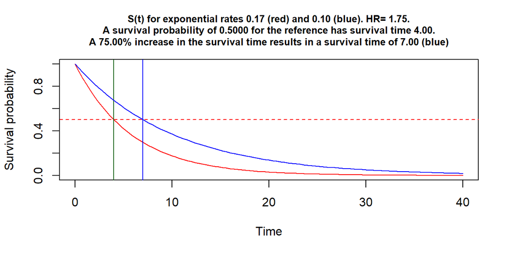

```r
#~~~~~~~~~~~~~~~~~~~~~~~~~~~~~~~~~~~~~~~~~~~~~~~~~~~~~~~~~~~~~~~~~~~~~~~~~~~~~~~~~~~~~~~~~~~~~~~~
# visualize the question
#~~~~~~~~~~~~~~~~~~~~~~~~~~~~~~~~~~~~~~~~~~~~~~~~~~~~~~~~~~~~~~~~~~~~~~~~~~~~~~~~~~~~~~~~~~~~~~~~

  end <- ceiling(-(log(1-.999)/ lambda))       # for plotting the range of x axis, calc. 99th percentile
  s   <- seq(0,end, length.out = end+1)

  curve(weibSurv(x, shape=1, scale=1/lambda), from=0, to=end,
        main=paste0("S(t) for exponential rates ",formatz2(lambda)," (red) and ",formatz2(lambda2), " (blue). HR= ",formatz2(hr),".\n A survival probability of ",formatz4(p)," for the reference has survival time ",
                    formatz2(-log(p)/lambda),". \nA ",formatz2(fact.*100) ,"% increase in the survival time results in a survival time of ",formatz2(-log(p)/lambda2)," (blue)"),  cex.main = .8,
        ylab='Survival probability', xlab='Time', col="red")

  abline(v= -log(p)/lambda, col='darkgreen')
  abline(h=p , col='red' , lty=2)
  abline(v= -log(p)/lambda2 , col='blue')

  curve(weibSurv(x, shape=1, scale=1/lambda2), from=0, to=end,
        ylab='Survival probability', xlab='Time', col="blue", add=TRUE)
```

# 14 Example 8 Plot many studies

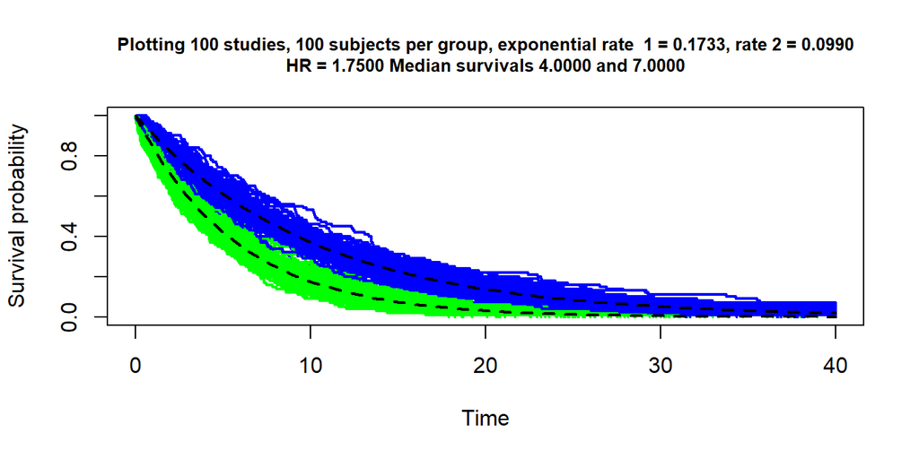

```r
#~~~~~~~~~~~~~~~~~~~~~~~~~~~~~~~~~~~~~~~~~~~~~~~~~~~~~~~~~~~~~~~~~~~~~~~~~~~~~~~~~~~~~~~~~~~~~~~~
# Plot many studies
#~~~~~~~~~~~~~~~~~~~~~~~~~~~~~~~~~~~~~~~~~~~~~~~~~~~~~~~~~~~~~~~~~~~~~~~~~~~~~~~~~~~~~~~~~~~~~~~~

  T1 <- 1/h* (-log(runif(n)))^(1)      # 1 in brackets dictates exponential dist
  T2 <- 1/h2*(-log(runif(n)))^(1)      # 1 in brackets dictates exponential dist

  survfit1 <- survfit(Surv(T1) ~ 1)
  plot(survfit1, ylab="Survival probability", xlab="Time",col="green", conf.int=FALSE,
       main=paste0("Plotting ",n," studies, ",n," subjects per group, exponential rate  1 = ",formatz4(h),", rate 2 = ",formatz4(h2), "\nHR = ",formatz4(h/h2),
                   " Median survivals ",formatz4(log(2)/lambda)," and ",formatz4(log(2)/lambda2)), xlim=c(0,end), cex.main = .8)

  survfit2 <- survfit(Surv(T2) ~ 1)
  lines(survfit2, lwd=2, col='blue', conf.int = FALSE)

  # draw 100 studies!
  for ( i in 1:n) {

    T1 <- 1/h* (-log(runif(n)))^(1)   # 1 in brackets dictates exponential dist
    T2 <- 1/h2*(-log(runif(n)))^(1)   # 1 in brackets dictates exponential dist

    survfit1 <- survfit(Surv(T1) ~ 1)
    lines(survfit1, lwd=2, col='green', conf.int = FALSE)

    survfit2 <- survfit(Surv(T2) ~ 1)
    lines(survfit2, lwd=2, col='blue', conf.int = FALSE)

  }

  # plot true survival curve, constant hazard h
  curve(weibSurv(x, shape=1, scale=1/h), from=0, to=end, n=length(T1),
        col='black', lwd=2, lty=2,
        ylim=c(0,1), add=TRUE)

  # plot true survival curve, constant hazard h2
  curve(weibSurv(x, shape=1, scale=1/h2), from=0, to=end, n=length(T1),
        col='black', lwd=2, lty=2,
        ylim=c(0,1), add=TRUE)
```

# 15 Example 8 Simulate

```r
#~~~~~~~~~~~~~~~~~~~~~~~~~~~~~~~~~~~~~~~~~~~~~~~~~~~~~~~~~~~~~~~~~~~~~~~~~~~~~~~~~~~~~~~~~~~~~~~~
# power simulation
#~~~~~~~~~~~~~~~~~~~~~~~~~~~~~~~~~~~~~~~~~~~~~~~~~~~~~~~~~~~~~~~~~~~~~~~~~~~~~~~~~~~~~~~~~~~~~~~~

  sim = function(h,h2,n) {

    # Simulate some time to event data
    T1 <- 1/h* (-log(runif(n)))^(1)
    T2 <- 1/h2*(-log(runif(n)))^(1)

    # data
    ti = c(T1, T2)
    gr = c(rep(1, n), rep(0, n))

    l = coxph(Surv(ti) ~ gr)    # Fit Cox model
    anova(l)$`Pr(>|Chi|)`[2]   # P-value
  }

  #set.seed(123) # Reproducible pseudorandom numbers
  pv <-  replicate(1000, sim(n = 200/2, h = h, h2=h2))
  mean(pv <= 0.05)
```

[1] 0.98

# 16 Example 8 use Hmisc::cpower

```r
#~~~~~~~~~~~~~~~~~~~~~~~~~~~~~~~~~~~~~~~~~~~~~~~~~~~~~~~~~~~~~~~~~~~~~~~~~~~~~~~~~~~~~~~~~~~~~~~~
# let's use Frank Harrell Hmisc cpower function
# the perspective here is change in mortality at initial time of interest rather
#~~~~~~~~~~~~~~~~~~~~~~~~~~~~~~~~~~~~~~~~~~~~~~~~~~~~~~~~~~~~~~~~~~~~~~~~~~~~~~~~~~~~~~~~~~~~~~~~
  morti <- function ( d0=.5, hr=2/3, time=6){

    lambda = -log(1-d0)/time     # hazard rate
    m = 1 - exp(-lambda*time*hr) # mortality hence subtracting from 1
    return(m)
  }

  time <- ms1
  d0   <- p
  hr   <- 1/hr

  d1 <- morti(d0=d0, hr= hr, time=time)

  # looking at graph above just made me choose accrual time 100 with no further follow up
  Hmisc::cpower(tref=time, n=100*2, mc=d0, r=100*(d0 - d1)/d0, accrual=100, tmin=0,
         noncomp.c=0, noncomp.i=0)
```

Accrual duration: 100 y Minimum follow-up: 0 y

Total sample size: 200

Alpha= 0.05

4-year Mortalities Control Intervention 0.5000000 0.3270499

Hazard Rates Control Intervention 0.17328680 0.09902103

Probabilities of an Event During Study Control Intervention 0.9422922 0.8990164

Expected Number of Events Control Intervention 94.2 89.9

Hazard ratio: 0.5714286 Standard deviation of log hazard ratio: 0.1474303 Power 0.966809

```r
    Hmisc::cpower(tref=time, n=152, mc=d0, r=100*(d0 - d1)/d0, accrual=100, tmin=0,
         noncomp.c=0, noncomp.i=0)
```

Accrual duration: 100 y Minimum follow-up: 0 y

Total sample size: 152

Alpha= 0.05

4-year Mortalities Control Intervention 0.5000000 0.3270499

Hazard Rates Control Intervention 0.17328680 0.09902103

Probabilities of an Event During Study Control Intervention 0.9422922 0.8990164

Expected Number of Events Control Intervention 71.6 68.3

Hazard ratio: 0.5714286 Standard deviation of log hazard ratio: 0.1691141 Power 0.9113536

# 17 Example 8 simulation again with another self written function

```r
 w.sim2 <- function(p=1, hr=1.75, n=100, At=30, ms=5.5, lambdaC=.04) {

      h  <- log(2)/ms                    # hazard for exponential
      ms <- 1/h*(-log(1-0.5))^(p)        # median survival
      T1 <- 1/h*(-log(runif(n)))^(p)     # weibull times, p=1 so exp, lambda=h

      ms2<- ms*hr                        # use the HR to get hazard in other group
      h2 <- log(2)/ms2
      T2 <- 1/h2*(-log(runif(n)))^(p)    # weibull times, p=1 so exp, lambda=h2

      # lambdaC hazard of censoring
      C1 = rweibull(n, shape=1, scale=1/lambdaC)   # censoring time
      C2 = rweibull(n, shape=1, scale=1/lambdaC)   # censoring time

      time1 = pmin(T1,C1)  # observed time is min of censored and true grp0
      time2 = pmin(T2,C2)  # observed time is min of censored and true grp1

      event1 = time1==T1
      event2 = time2==T2

      event = c(event1,event2)
      #~~~~~~~~~~~~~~~~~~~~~~~~~~~~~~~~~~~~~~~~~~~~~~~~~~~~~~~~~~~~~~~~~~~~~
      dat <- data.frame(T = c(time1,time2),
                        x = c(rep(1,n), rep(0,n)),
                        event = c(event1,event2) )

      l = coxph(Surv(T, event) ~ x, dat)

      pv <- anova(l)$`Pr(>|Chi|)`[2] # P-value from likelihood ratio test

      # collect
      o <- pv

      n <- (l$n-l$nevent)/l$n

      p <- exp(l$coefficients[[1]])

      ev <- l$nevent

   #   pow <- o <=.05

      output <- list(o,n,p,ev )

      return(output)

    }


  fact.    <-   (7-4)/4  # % increase in time for survival of this means
  lambda   <-  log(2)/4 # baseline hazard (reference)
  lambda2  <-  lambda/(1+fact.)
  hr       <-  lambda/lambda2


  # need to double check inputs are correct here??
  require(survival)
  phr = replicate(1000, w.sim2(p=1, hr=hr, n=200/2, At=30000, ms=7, lambdaC=0.00006)) # # censoring and admin censoring times are so big they have no effect
  phr <- t(phr)
  mean(phr[,1] <= 0.05)
```

[1] 0.97

# 18 Example 9 non inferiority, checking the 90% confidence of the HR to a non inferiority margin

```r
#~~~~~~~~~~~~~~~~~~~~~~~~~~~~~~~~~~~~~~~~~~~~~~~~~~~~~~~~~~~~~~~~~~~~~~~~~~~~~~~~~~~~~~~~~~~~~~~~
# non inf power simulation - under construction
#~~~~~~~~~~~~~~~~~~~~~~~~~~~~~~~~~~~~~~~~~~~~~~~~~~~~~~~~~~~~~~~~~~~~~~~~~~~~~~~~~~~~~~~~~~~~~~~~
  # inputs
  n     <- 100                             # no of patients per group
  ms1   <- 4                               # median survival null
  ms2   <- 7                               # median survival alternative
  p     <- 0.50                            # time for survival probability
  fact. <- (ms2-ms1)/ms1                   # % increase in time for survival of this means
  h     <- lambda   <-  log(2)/ms1         # baseline hazard (reference)
  h2    <- lambda2  <-  lambda/(1+fact.)   # alternate hazard
  hr    <- lambda/lambda2                  # hr compare


  simi = function(h,h2,n) {

    # Simulate some time to event data
    T1 <- 1/h* (-log(runif(n)))^(1)
    T2 <- 1/h2*(-log(runif(n)))^(1)

    # data
    ti = c(T1, T2)
    gr = c(rep(1, n), rep(0, n))

    l = coxph(Surv(ti) ~ gr)    # Fit Cox model
    #anova(l)$`Pr(>|Chi|)`[2]   # P-value
    exp(confint(l, level = .9))  [1][[1]]  # use for lower CI

  }

  #set.seed(123) # Reproducible pseudorandom numbers
  # try less samples
  pv <-  replicate(1000, simi(n = 50/2, h = h, h2=h2))
  mean(pv >  0.80)
```

[1] 0.86

```r
  mean(pv >  0.85)
```

[1] 0.796

```r
  mean(pv >  0.90)
```

[1] 0.737

```r
  mean(pv >  0.95)
```

[1] 0.668

```r
 # mean(pv > 1.0)
#  mean(pv > 1.1)
#  mean(pv > 1.2)
```

```
[1] "C:/Users/Lenovo/Documents/Survival-power"
```

This took 50.19 seconds to execute.